1- How many lines are there in the dataframe? How much space does it consume in your memory?

```python
#Number of lines in the data
import pandas as pd
ct = pd.read_csv("202005171549_corona_tweets.csv")
index = ct.index
number_of_rows = len(index)
print(number_of_rows)
```

```
541793
```

```python
#Space the data frame consumes
import pandas as pd
ct = pd.read_csv("202005171549_corona_tweets.csv")
print("The space this dataframe uses in terms of bytes is", ct.memory_usage(index=True).sum())
```

```
The space this dataframe uses in terms of bytes is 82894457
```

2- What are the column names?

```python
import pandas as pd
ct = pd.read_csv("202005171549_corona_tweets.csv")
ct_list = list(ct.head())
print(ct_list)
```

```
['Unnamed: 0', 'Unnamed: 0.1', 'coordinates', 'country', 'created_at', 'device', 'entity_hashtags', 'entity_mentions', 'entity_type', 'entity_urls', 'id_str', 'in_reply_to_user_id', 'is_retweet', 'screen_name', 'text', 'tweet_location', 'user_followers', 'user_following', 'user_id', 'user_location']
```

3- Identify the most tweeting 50 users. The value_counts() method will help you

```python
import pandas as pd
ct = pd.read_csv("202005171549_corona_tweets.csv")
df = ct['user_id'].value_counts()
df.head(50)
```

```
19087092               312
369315889              309
246134823              275
1231590638             265
17694306               242
886675788              179
1133549569436987393    145
19708473               140
757358178044678144     133
753571509080174592     130
289118612              128
212457705              114
58371354               111
1222133856469504000    111
29519681               104
```

[output cut: 36 more lines]

4- Plot a histogram of the 50 most tweeting users. Do not forget to include an xlabel, ylabel, and a title on your figure.

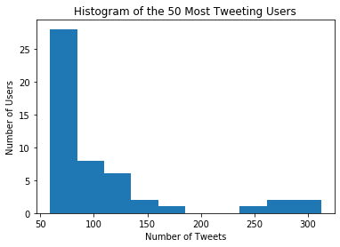

```python
import pandas as pd
import matplotlib.pyplot as plt
ct = pd.read_csv("202005171549_corona_tweets.csv")
x = list (ct['user_id'].value_counts())
df = x[:50]
import matplotlib.pyplot as plt
plt.hist(df, bins=10)
plt.xlabel('Number of Tweets')
plt.ylabel('Number of Users')
plt.title('Histogram of the 50 Most Tweeting Users')
```

```python
5- Identify duplicate tweets based on the 'text' field.
```

```python
import pandas as pd
ct = pd.read_csv("202005171549_corona_tweets.csv")
duplicated_rows = ct['text'].duplicated(keep= False)
duplicated_rows
```

```
0         False
1          True
2         False
3          True
4          True
          ...
541788     True
541789     True
541790     True
541791     True
541792     True
Name: text, Length: 541793, dtype: bool
```

6- Remove duplicate tweets based on the 'text' field. How many tweets do you have now?

```python
import pandas as pd
ct = pd.read_csv("202005171549_corona_tweets.csv")
ct["text"].drop_duplicates (inplace = True)
ct
```

|  | Unnamed: 0 | Unnamed: 0.1 | coordinates | country | created_at | device | entity_hashtags | entity_mentions | entity_type | entity_urls | id_str | in_reply_to_user_id | is_retweet | screen_name | text | tweet_location | user_followers | user_following | user_id | user_location |
| --- | --- | --- | --- | --- | --- | --- | --- | --- | --- | --- | --- | --- | --- | --- | --- | --- | --- | --- | --- | --- |
| 0 | 34646 | 34646 | NaN | NaN | 2020-03-03 02:49:50 | Twitter for iPhone | [] | [] | NaN | ['twitter.com/i/web/status/1…'] | 1234672302903590913 | NaN | False | Manny_Alicandro | Every 3 days? Coronavirus in NY? Workers will... | NaN | 9125 | 4872 | 992623688028774400 | NY |
| 1 | 34647 | 34647 | NaN | NaN | 2020-03-03 02:49:50 | Twitter for Android | [] | ['shobey_edits'] | NaN | [] | 1234672302647738370 | NaN | True | wodzd | RT @shobey_edits: sent a mail to marvel ent, r... | NaN | 3123 | 3103 | 1086492406466277377 | 𝐗𝐎𝐧𝐞𝐈𝐭 |
| 2 | 34648 | 34648 | NaN | NaN | 2020-03-03 02:49:50 | Twitter for iPhone | [] | ['realDonaldTrump'] | NaN | ['twitter.com/i/web/status/1…'] | 1234672301888532480 | 25073877.0 | False | mom2speak1 | @realDonaldTrump Wow, a nice incubator for COV... | NaN | 313 | 1149 | 800391394191810560 | United States |
| 3 | 34649 | 34649 | NaN | NaN | 2020-03-03 02:49:50 | Twitter Web App | [] | ['uk_domain_names'] | NaN | [] | 1234672301712347136 | NaN | True | lazaroumterror | RT @uk_domain_names: "UK and Scottish governme... | NaN | 3871 | 3935 | 19881915 | London |
| 4 | 34650 | 34650 | NaN | NaN | 2020-03-03 02:49:50 | Twitter Web App | [] | ['LanceHoward70'] | NaN | [] | 1234672300584103936 | NaN | True | astro_stephen13 | RT @LanceHoward70: This 👇 is the leader of the... | NaN | 538 | 367 | 148663 | Georgia, USA |
| ... | ... | ... | ... | ... | ... | ... | ... | ... | ... | ... | ... | ... | ... | ... | ... | ... | ... | ... | ... | ... |
| 541788 | 1048570 | 1050544 | NaN | NaN | 2020-02-29 17:56:27 | Twitter for Android | ['COVID19'] | ['Laurie_Garrett'] | NaN | [] | 1233813296135987201 | NaN | True | Who_IsM | RT @Laurie_Garrett: If the US govt keeps billi... | NaN | 1937 | 4996 | 968640829 | Earth |
| 541789 | 1048571 | 1050545 | NaN | NaN | 2020-02-29 17:56:27 | Twitter for iPhone | ['coronavirus'] | ['tancredipalmeri'] | NaN | [] | 1233813295561355264 | NaN | True | orionmaggi | RT @tancredipalmeri: The #coronavirus cases in... | NaN | 162 | 587 | 794726696 | New England |
| 541790 | 1048572 | 1050546 | NaN | NaN | 2020-02-29 17:56:25 | Twitter for iPhone | [] | ['treasonstickers'] | NaN | [] | 1233813288930226176 | NaN | True | Peace_NH | RT @treasonstickers: FUN FACT: Donald Trump is... | NaN | 594 | 434 | 2511294116 | New Hampshire |
| 541791 | 1048573 | 1050547 | NaN | NaN | 2020-02-29 17:56:25 | Twitter for iPhone | [] | ['washingtonpost'] | NaN | [] | 1233813288644792320 | NaN | True | avoidchaos | RT @washingtonpost: DHS employee told to repor... | NaN | 766 | 518 | 1177196383 | Los Angeles, CA |
| 541792 | 1048574 | 1050548 | NaN | NaN | 2020-02-29 17:56:25 | Twitter for iPhone | [] | ['delta_su', 'bajas_k'] | NaN | [] | 1233813287852097538 | NaN | True | NewImproved9 | RT @delta_su: @bajas_k Maybe he is in self qua... | NaN | 3507 | 3591 | 944714037241114624 | British Columbia, Canada |

541793 rows × 20 columns

```python
number_of_rows= len(ct["text"])
print('Number of tweets remaining is', number_of_rows)
```

[output not shown]

7- Replace all users names in the 'text' field with the usrusr token. You need to write a regular expression that identify user names and use the replace method to replace it with the 'usrusr' token. For instance:

"Are you there @ahurriyetoglu" should be "Are you there usrusr"

```python
import pandas as pd
import re
ct['text'] = ct['text'].replace(
    to_replace='@\w+', value='usrusr', regex=True)
ct
```

|  | Unnamed: 0 | Unnamed: 0.1 | coordinates | country | created_at | device | entity_hashtags | entity_mentions | entity_type | entity_urls | id_str | in_reply_to_user_id | is_retweet | screen_name | text | tweet_location | user_followers | user_following | user_id | user_location |
| --- | --- | --- | --- | --- | --- | --- | --- | --- | --- | --- | --- | --- | --- | --- | --- | --- | --- | --- | --- | --- |
| 0 | 34646 | 34646 | NaN | NaN | 2020-03-03 02:49:50 | Twitter for iPhone | [] | [] | NaN | ['twitter.com/i/web/status/1…'] | 1234672302903590913 | NaN | False | Manny_Alicandro | Every 3 days? Coronavirus in NY? Workers will... | NaN | 9125 | 4872 | 992623688028774400 | NY |
| 1 | 34647 | 34647 | NaN | NaN | 2020-03-03 02:49:50 | Twitter for Android | [] | ['shobey_edits'] | NaN | [] | 1234672302647738370 | NaN | True | wodzd | RT usrusr: sent a mail to marvel ent, regardin... | NaN | 3123 | 3103 | 1086492406466277377 | 𝐗𝐎𝐧𝐞𝐈𝐭 |
| 2 | 34648 | 34648 | NaN | NaN | 2020-03-03 02:49:50 | Twitter for iPhone | [] | ['realDonaldTrump'] | NaN | ['twitter.com/i/web/status/1…'] | 1234672301888532480 | 25073877.0 | False | mom2speak1 | usrusr Wow, a nice incubator for COVID-19! But... | NaN | 313 | 1149 | 800391394191810560 | United States |
| 3 | 34649 | 34649 | NaN | NaN | 2020-03-03 02:49:50 | Twitter Web App | [] | ['uk_domain_names'] | NaN | [] | 1234672301712347136 | NaN | True | lazaroumterror | RT usrusr: "UK and Scottish government modelli... | NaN | 3871 | 3935 | 19881915 | London |
| 4 | 34650 | 34650 | NaN | NaN | 2020-03-03 02:49:50 | Twitter Web App | [] | ['LanceHoward70'] | NaN | [] | 1234672300584103936 | NaN | True | astro_stephen13 | RT usrusr: This 👇 is the leader of the free wo... | NaN | 538 | 367 | 148663 | Georgia, USA |
| ... | ... | ... | ... | ... | ... | ... | ... | ... | ... | ... | ... | ... | ... | ... | ... | ... | ... | ... | ... | ... |
| 541788 | 1048570 | 1050544 | NaN | NaN | 2020-02-29 17:56:27 | Twitter for Android | ['COVID19'] | ['Laurie_Garrett'] | NaN | [] | 1233813296135987201 | NaN | True | Who_IsM | NaN | NaN | 1937 | 4996 | 968640829 | Earth |
| 541789 | 1048571 | 1050545 | NaN | NaN | 2020-02-29 17:56:27 | Twitter for iPhone | ['coronavirus'] | ['tancredipalmeri'] | NaN | [] | 1233813295561355264 | NaN | True | orionmaggi | NaN | NaN | 162 | 587 | 794726696 | New England |
| 541790 | 1048572 | 1050546 | NaN | NaN | 2020-02-29 17:56:25 | Twitter for iPhone | [] | ['treasonstickers'] | NaN | [] | 1233813288930226176 | NaN | True | Peace_NH | NaN | NaN | 594 | 434 | 2511294116 | New Hampshire |
| 541791 | 1048573 | 1050547 | NaN | NaN | 2020-02-29 17:56:25 | Twitter for iPhone | [] | ['washingtonpost'] | NaN | [] | 1233813288644792320 | NaN | True | avoidchaos | NaN | NaN | 766 | 518 | 1177196383 | Los Angeles, CA |
| 541792 | 1048574 | 1050548 | NaN | NaN | 2020-02-29 17:56:25 | Twitter for iPhone | [] | ['delta_su', 'bajas_k'] | NaN | [] | 1233813287852097538 | NaN | True | NewImproved9 | NaN | NaN | 3507 | 3591 | 944714037241114624 | British Columbia, Canada |

541793 rows × 20 columns

8-Replace all URLs with 'urlurl' token in the 'text' column. For instance:

"Please visit http://ku.edu.tr" should be "Please visit urlurl".

```python
ct['text'] = ct['text'].replace(
    to_replace = 'http[^\ ]*', value='urlurl', regex=True)
ct['text']
```

```
0         Every 3 days? Coronavirus in NY?  Workers will...
1         RT usrusr: sent a mail to marvel ent, regardin...
2         usrusr Wow, a nice incubator for COVID-19! But...
3         RT usrusr: "UK and Scottish government modelli...
4         RT usrusr: This 👇 is the leader of the free wo...
                                ...
541788                                                  NaN
541789                                                  NaN
541790                                                  NaN
541791                                                  NaN
541792                                                  NaN
Name: text, Length: 541793, dtype: object
```

9- If a tweet starts with "RT @", it is a retweet. Remove all retweets from the dataframe.

```python
filter = ct['text'].str.contains('RT usrusr')
ct = ct[~filter]
ct
```

[output not shown]

541793 rows × 20 columns

10- If the field is_retweet contains the value True, this tweet is a retweet as well. Remove those as well.

```python
new_ct = ct['is_retweet']
ct = ct[~new_ct]
ct
```

[output not shown]

80103 rows × 21 columns

11- Check how many duplicate tweets are there. Remove them. How many tweets do you have now?

```python
import pandas as pd
ct.drop_duplicates(keep='first').shape
```

```
(80103, 20)
```

12- Plot a histogram of the text lengths. What is the length of the longest and the shortest tweets? 4- Plot a histogram of the 50 most tweeting users. Do not forget to include an xlabel, ylabel, and a title on your figure.

[figure not shown]

```python
#Histogram of the text lengths
import pandas as pd
import matplotlib.pyplot as plt
plt.hist(ct["text"].str.len())
plt.ylabel("Tweets Posted")
plt.xlabel("Length of Tweets")
plt.title("Histogram of The Text Lengths")
```

```python
#longest and the shortest tweets

print("Length of the shortest tweet:", ct["text"].str.len().min())
print("Length of the shortest tweet:", ct["text"].str.len().max())
```

```
Length of the shortest tweet: 8
Length of the shortest tweet: 161
```

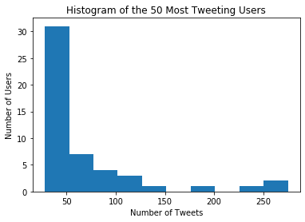

```python
#Histogram of the 50 most tweeting users
x = list (ct['user_id'].value_counts())
df = x[:50]
import matplotlib.pyplot as plt
plt.hist(df, bins=10)
plt.xlabel('Number of Tweets')
plt.ylabel('Number of Users')
plt.title('Histogram of the 50 Most Tweeting Users')
```

13- Calculate the average tweet length based on the 'text' field.

```python
import pandas as pd
import re
ct = pd.read_csv("202005171549_corona_tweets.csv")
result = ct["text"].apply(len).mean()
print(result)
```

```
132.92917959442076
```

14- Extract all words from the 'text' field and put them in a new column. The findall method and a regular expression to recognize words will help you.

```python
ct['extracted'] = ct['text'].str.findall('\w+')
ct['extracted']
```

```
0         [Every, 3, days, Coronavirus, in, NY, Workers,...
1         [RT, shobey_edits, sent, a, mail, to, marvel, ...
2         [realDonaldTrump, Wow, a, nice, incubator, for...
3         [RT, uk_domain_names, UK, and, Scottish, gover...
4         [RT, LanceHoward70, This, is, the, leader, of,...
                                ...
541788    [RT, Laurie_Garrett, If, the, US, govt, keeps,...
541789    [RT, tancredipalmeri, The, coronavirus, cases,...
541790    [RT, treasonstickers, FUN, FACT, Donald, Trump...
541791    [RT, washingtonpost, DHS, employee, told, to, ...
541792    [RT, delta_su, bajas_k, Maybe, he, is, in, sel...
Name: extracted, Length: 541793, dtype: object
```

15- Identify the words that occur the most. The Counter object from collections will help you.

```python
import collections
counter = collections.Counter()
for row in ct['extracted']:
    for word in row:
        counter[word] += 1

for word in counter.most_common(100):
    print(word[0])
```

```
RT
the
to
of
coronavirus
in
t
a
https
co
Coronavirus
is
and
are
for
s
from
has
outbreak
have
people
I
The
that
on
by
you
cases
with
Trump
it
They
help
public
donated
about
not
new
COVID19
this
```

[output cut: 45 more lines]

```
BREAKING
should
This
everyday
currently
will
can
all
A
his
Democrats
been
virus
they
We
```

17- Find the longest 100 words. List them.

```python
for word in counter.most_common():
    length_counter[word[0]] = len(word[0])

for word in length_counter.most_common(100):
    print(word[0])
```

[output not shown]

18- Find tweets that are all in upper case, such as "THIS IS A TWEET ALL UPPER CASE." in their 'text' field.

```python
uc_tweets = ct[ct['text'].str.isupper()]['text']

print(uc_tweets)
```

```
1516                                     @BORN4WIN COVID-19
1760                                     @BORN4WIN COVID-19
2766                            #ブタゴリラに匹敵する強そうなあだ名 COVID-19
3644                                   @BORN4WIN A)COVID-19
6759                               COVID-19/PROJECT-THANOS.
14240                                              COVID-19
20520                                              COVID-19
21517                                              COVID-19
22140                                         @ABC COVID-19
31791     IRAN HEALTH AUTHORITIES CONFIRMED 9 DEATHS FRO...
32172     QATAR ANNOUNCES FIRST CASE OF CORONAVIRUS INFE...
33198     RT @INVESTMENTSHULK: ISSUING CORRECTION ON A P...
37925     IRAN HEALTH AUTHORITIES CONFIRMED 295 FRESH CA...
41337     QATAR ANNOUNCES FIRST CASE OF CORONAVIRUS INFE...
43377     QATAR ANNOUNCES FIRST CASE OF CORONAVIRUS INFE...
```

[output cut: 43 more lines]

19- Identify the mostly occurring 50 hashtags.

```python
import collections
counter2 = collections.Counter()
hashtags = ct['entity_hashtags'].str.findall('\w+')
for row in hashtags:
    for hashtag in row:
        counter2[hashtag] += 1

for hashtag in counter2.most_common(50):
    print(hashtag[0])
```

```
coronavirus
Coronavirus
COVID19
CoronaVirus
Iran
CoronavirusOutbreak
COVIDー19
COVID2019
china
China
creativity
BREAKING
CoronaVirusUpdates
hoax
BTS
COVID
SARSCoV2
Wuhan
COVID19Nigeria
covid19
Covid19
Israeli
Covid_19
Italy
2019_nCov
Hoax
Coronavid19
ARMY
HongKong
Resistance
SouthKorea
Trump
CoronavirusKe
CDC
Beijing
CoronaVirusUpdate
TGTrans
NovelCoronaVirus
COVID19US
TrumpRallyCharleston
BTSARMY
JINU
COVAD19
Haiti
DominicanRepublic
PublicHealth
coronavirusnigeria
Japan
IndiaHidingCoronaStrike
US
```

20- Export the final dataframe to csv and Excel files.

```python
new_ct.to_csv('finaldataframe.csv')
new_ct.to_excel('finaldataframe.xlsx')
```

# Extra Question

21- Plot a histogram of the devices used to tweet.

```python
import matplotlib.pyplot as plt
data = ct['device'].value_counts().to_frame().style.bar()
data
```

|  | device |
| --- | --- |
| Twitter for iPhone | 19290 |
| Twitter Web App | 18995 |
| Twitter for Android | 15792 |
| Twitter Web Client | 6006 |
| IFTTT | 3131 |
| Twitter for iPad | 2997 |
| WordPress.com | 1959 |
| TweetDeck | 1910 |
| dlvr.it | 1727 |
| Hootsuite Inc. | 853 |
| Buffer | 486 |
| SocialFlow | 433 |
| The Tweeted Times | 382 |
| the paper link | 275 |
| SocialNewsDesk | 264 |
| Echobox Social | 221 |
| LinkedIn | 189 |
| Orange Room automatic tweet | 179 |
| Instagram | 179 |
| Tweetbot for iΟS | 155 |
| True Anthem | 146 |
| Google | 135 |
| The Social Jukebox | 130 |
| Twibble.io | 128 |
| Sprout Social | 111 |
| Paper.li | 99 |
| Nuzzel | 86 |
| SmartNews \| スマートニュース | 84 |
| TweetCaster for Android | 80 |
| EcoInternet3 | 79 |

[output cut: 887 more lines]